# Fuzzy transfromācijas un to lietojumi Volterra integrālvienādojumu risināšanā.

Šajā rakstā tiek aplūkota fuzzy transfromācija un kā tā tiek leitota skaitliskai integrālvienādojumu risināšanā.

### Definīcija

Lai $x_{1} < \ldots < x_{n}$ ir fiksēti punkti intervālā [a,b] tā, ka $a=x_{1}, x_{n} = b$ un $n \geq 2$. Tad nestriktās kopas $A_{1}, \ldots, A_{n}$ ar attiecīgi piederības funkcijām $A_{1}(x), \ldots, A_{n}(x)$, kuras ir definētas intervālā [a,b], ir bāzes funkcijas, ja izpildās:

1. $A_{k}(x):[a,b]\to[0,1]$
2. $A_{k}(x)=0 $, ja $x\notin (x_{k-1},x_{k+1})$
3. $A_{k}$ ir nepārtraukta
4. $A_{k}(x)$, $k=2,\ldots,n$ stingri aug, kad $x\in [x_{k-1},x_{k}]$ un $ A_{k}(x)$, $k= 1, \ldots n-1 $ stringri dilst, kad $ x\in [x_{k},x_{k+1}] $
5. $\forall x\in [a,b], \sum\limits^{n}_{k=1} A_{k}(x)= 1 $

#### Piemērs

Trijstūra bāzes funckijas

$$ A_{1}(x) = \begin{cases} 1 - \frac{x- x_{1}}{h_{1}} \text{ if } x \in [x_{1},x_{2}]\\ 0 \text{ citādi } \end{cases} $$$$ A_{k}(x) = \begin{cases} \frac{x- x_{k-1}}{h_{k-1}} \text{ if } x \in [x_{k-1},x_{k}]\\ 1 - \frac{x- x_{k}}{h_{k}} \text{ if } x \in [x_{k},x_{k+1}]\\ 0 \text{ citādi } \end{cases} $$$$ A_{n}(x) = \begin{cases} \frac{x- x_{n-1}}{h_{n-1}} \text{ if } x \in [x_{n-1},x_{n}]\\ 0 \text{ citādi } \end{cases} $$

Turpmāk visiem $k = 1,\ldots, n$ tiks lietots vienmērīgs soļa garums, $ h = \frac{b-a}{n-1}$

```python
import numpy as np
import matplotlib.pyplot as plt
from PIL import Image

import warnings
warnings.filterwarnings("ignore")

def bazes_fun(k,a,b):

    # soļa garums
    h = (b-a)/(k-1)

    # režģis
    xx_k = np.arange(a,b+h,h)

    # Saraksts bāzes funkcijām
    A_basic_fun = []

    ### Tālāk devinē trijstūra bāzes funkcijas

    # Vispirms pirmo (labā trijstūra mala)
    A_basic_fun.append(lambda x: max(0, 1 -(x[0]-xx_k[0])/h))

    for id_x, xk in enumerate(xx_k[1:-1],start =1):
        A_basic_fun.append( lambda x:  max( min(  (x[0]- xx_k[x[1]-1])/h, 1- ( x[0] - xx_k[x[1]])/h ),0 ))

    # Beigās pievieno pēdējo (tikai kreisā mala trijstūrim)
    A_basic_fun.append( lambda x:  max(0,  ( x[0]-xx_k[-2])/h))

    return [A_basic_fun,h,xx_k]
```

# Fuzzy-transform jeb F-transform

### Definčija (integrālā transformācija)

Lai $A_{1}, \ldots, A_{n}$ ir bāzes funkcijas intervāla [a,b] un f ir kāda nepārtrautka funckija $f\in C([a,b])$, tad vektors $ \textbf{F}_{n}[f] = [F_{1}, \ldots F_{n}]$ ir funkcijas F-transformācija, kur

$$ F_{k} = \frac{\int^{b}_{a}A_{k}(x)f(x)dx}{\int^{b}_{a}A_{k}(x)dx} $$

Ir spēkā

$$ F_{1} = \frac{2}{h} \int_{x_{1}}^{x_{2}} f(x)A_{1}(x) dx$$$$ F_{n} = \frac{2}{h} \int_{x_{n-1}}^{x_{n}} f(x)A_{n}(x) dx$$$$ F_{k} = \frac{1}{h} \int_{x_{k-1}}^{x_{k+1}} f(x)A_{k}(x) dx, k = 2,\ldots n-1$$

```python
import scipy.integrate as integrate

def F_transform(f,A,h,xx_k):
    F_t = []
    F_t.append(2/h* integrate.quad(lambda x: f(x) *A[0]([x,0]) , xx_k[0], xx_k[1])[0])
    for id_x, x_k in enumerate(xx_k[1:-1],start =1):
        F_t.append( 1/h * integrate.quad(lambda x: f(x) * A[id_x]([x,id_x]) , xx_k[id_x-1], xx_k[id_x+1])[0] )
    F_t.append(  2/h * integrate.quad(lambda x: f(x) * A[-1]([x,-1]) , xx_k[-2], xx_k[-1])[0]  )
    return F_t
```

### Definīcija

Lai $A_{1}, \ldots A_{n}$ ir bāzes funkcijas intervālā [a,b], $f\in C([a,b])$ un $ \textbf{F}_{n}[f] = [F_{1},\ldots F_{n}]$ ir funkciajs f integrāl F-transformācija attiecībā pret bāzes funkcijām $A_{1}, \ldots A_{n}$. Tad inversā transformācija

$$ f_{F,n}(x) = \sum^{n}_{k=1}F_{k}A_{k}(x)$$

### Teorēma

Lai f ir nepārtraukta intervālā [a,b]. Tad katram $\varepsilon > 0 $ eksistē tāds $n_{\varepsilon} $ un bāzes funkcijas $A_{1}, \ldots A_{n_{\varepsilon}}$ tā, ka ja $x\in [a,b]$, tad $ \big| f(x) - f_{F,n_{\varepsilon}}(x) \big| \leq \varepsilon $

kur $f_{F,n_{\varepsilon}}$ ir funkcijas f inversā F-transformācija pret $A_{1}, \ldots, A_{n_{\varepsilon}}$

```python
# Dotajā punktā atrod inverso f transformāciju.
def inversa_transformacija(x,F_k,A):
    inversa_vert = 0

    for id, funkcija in enumerate(A):
        inversa_vert +=  funkcija([x,id]) * F_k[id]

    return inversa_vert
```

### Piemērs:

$f(x) = (x-1)(x-2)(2x-3) + 6 $

Funkcijai tik atrasta F-trasnfromācija intervālā [0,3] un pēc tam inversā transfromācija. Rezultāts tiek salīdzināts ar doto funkciju grafiski.

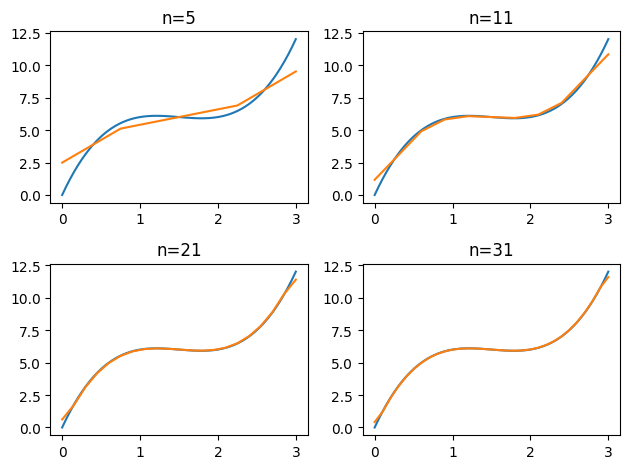

```python
Kv = [5,11,21,31]
titles = ['n=5', 'n=11', 'n=21', 'n=31']
f = lambda x: (x-1) * (x-2)* ( 2*x -3 ) + 6
a=0
b=3
fig, axs = plt.subplots(2, 2)
X = np.arange(a,b+0.01, 0.01 )
Y_fun = (X-1) * (X-2)* ( 2*X -3 ) + 6

for i in range(2):
    for j in range(2):
        id = i * 2 + j
        k = Kv[id]
        title = titles[id]

# Izviedo bāzes funkcijas
        [A,h,xx_k] = bazes_fun(k,a,b)

# Atrod funkcijai f (polinomam) F-transformācija
        F_t = F_transform(f,A,h,xx_k)
        Y_inversa =[]
        axs[i,j].plot(X,Y_fun)
        Y_inversa = []

# Iet cauri katram režģa punktam no X un atrod inverso transfromāciju.
        for xi in X:
            Y_inversa.append(inversa_transformacija(xi,F_t,A))
        axs[i,j].plot(X,Y_inversa)
        axs[i, j].set_title(title)

plt.tight_layout()
plt.show()
```

### Piemērs

$f(x) = \sin(x) x^{3} + \cos(x)$ intervālā [-1,1]

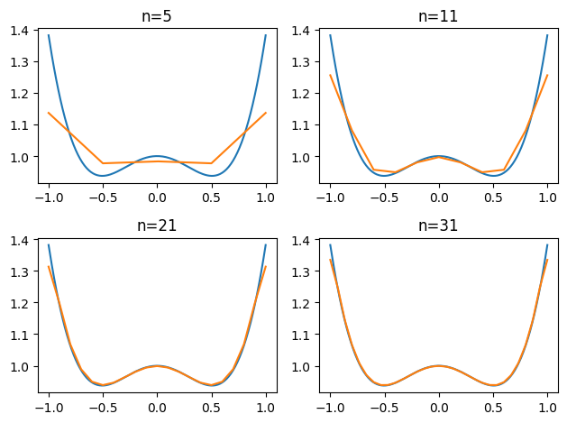

```python
Kv = [5,11,21,31]
titles = ['n=5', 'n=11', 'n=21', 'n=31']
f = lambda x: np.sin(x) * x**3 + np.cos(x)
a=-1
b=1
fig, axs = plt.subplots(2, 2)
X = np.arange(a,b+0.01, 0.01 )
Y_fun = np.sin(X) * X**3 + np.cos(X)

for i in range(2):
    for j in range(2):
        id = i * 2 + j
        k = Kv[id]
        title = titles[id]

# Izviedo bāzes funkcijas
        [A,h,xx_k] = bazes_fun(k,a,b)

# Atrod funkcijai f (polinomam) F-transformācija
        F_t = F_transform(f,A,h,xx_k)
        Y_inversa =[]
        axs[i,j].plot(X,Y_fun)
        Y_inversa = []

# Iet cauri katram režģa punktam no X un atrod inverso transfromāciju.
        for xi in X:
            Y_inversa.append(inversa_transformacija(xi,F_t,A))
        axs[i,j].plot(X,Y_inversa)
        axs[i, j].set_title(title)

plt.tight_layout()
plt.show()
```

Veicot F-transfromāciju ir pieņēmums, ka funkcija f ir nepārtraukta. Bet kas notiek, ja tiek veikta transformācija pārtrauktai funkcijai?

$$ f(x) = \begin{cases} 1 \text{ ja } x > 0.5\\ 0 \text{ citādi } \end{cases} $$

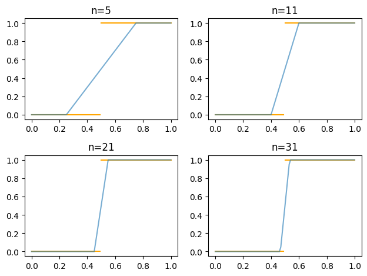

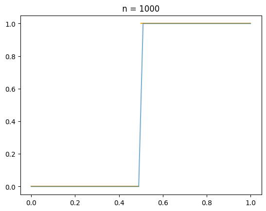

```python
Kv = [5,11,21,31]
titles = ['n=5', 'n=11', 'n=21', 'n=31']
f = lambda x:  (x> 0.5)
a=0
b=1
fig, axs = plt.subplots(2, 2)
X = np.arange(a,b+0.01, 0.01 )

x1 = np.arange(a,0.5, 0.01 )
x2 = np.arange(0.5, b+0.01, 0.01 )
Y1 =  np.zeros((x1.shape[0],1))
Y2 =  np.ones((x2.shape[0],1))

for i in range(2):
    for j in range(2):
        id = i * 2 + j
        k = Kv[id]
        title = titles[id]

# Izviedo bāzes funkcijas
        [A,h,xx_k] = bazes_fun(k,a,b)

# Atrod funkcijai f (polinomam) F-transformācija
        F_t = F_transform(f,A,h,xx_k)
        Y_inversa =[]
        axs[i,j].plot(x1,Y1,  '#FFA500')
        axs[i,j].plot(x2,Y2,'#FFA500')
        Y_inversa = []

# Iet cauri katram režģa punktam no X un atrod inverso transfromāciju.
        for xi in X:
            Y_inversa.append(inversa_transformacija(xi,F_t,A))
        axs[i,j].plot(X,Y_inversa,  alpha = 0.6)
        axs[i, j].set_title(title)

plt.tight_layout()
plt.show()


#### Ņemot n= 1000

f = lambda x:  (x> 0.5)
a=0
b=1
X = np.arange(a,b+0.01, 0.01 )

x1 = np.arange(a,0.5, 0.01 )
x2 = np.arange(0.5, b+0.01, 0.01 )
Y1 =  np.zeros((x1.shape[0],1))
Y2 =  np.ones((x2.shape[0],1))
[A,h,xx_k] = bazes_fun(1000,a,b)
F_t = F_transform(f,A,h,xx_k)
Y_inversa =[]
plt.plot(x1,Y1,  '#FFA500')
plt.plot(x2,Y2,'#FFA500')
Y_inversa = []

for xi in X:
            Y_inversa.append(inversa_transformacija(xi,F_t,A))
plt.plot(X,Y_inversa,  alpha = 0.6)
plt.title(" n = 1000 ")
plt.show()
```

Šajā piemērā, ņemot pietiekami lielu n, inversā transfromācija sasniegs funkciju f.

### Piemērs

$$ f(x) = \begin{cases} x^{2} \text{ ja } x < 0.5\\ \sqrt{x} \text{ ja } x > 0.5 \end{cases} $$

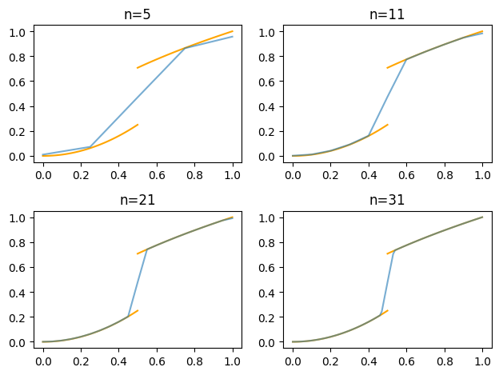

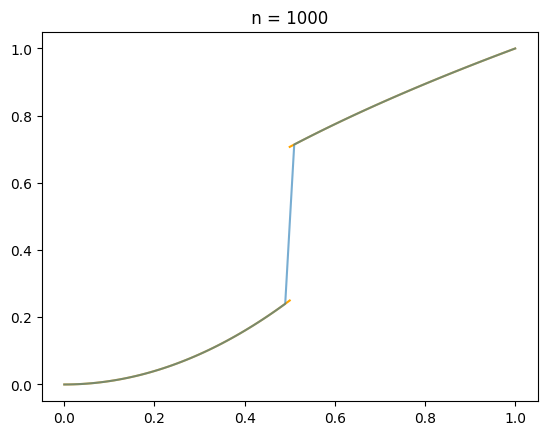

```python
Kv = [5,11,21,31]
titles = ['n=5', 'n=11', 'n=21', 'n=31']
f = lambda x:   x**(2) * (x <  0.5) + x**(1/2) * (x> 0.5)
a=0
b=1
fig, axs = plt.subplots(2, 2)
X = np.arange(a,b+0.01, 0.01 )

x1 = np.arange(a,0.5+0.01, 0.01 )
x2 = np.arange(0.5, b+0.01, 0.01 )
Y1 =   x1**(2)
Y2 =  np.sqrt(x2)

for i in range(2):
    for j in range(2):
        id = i * 2 + j
        k = Kv[id]
        title = titles[id]

# Izviedo bāzes funkcijas
        [A,h,xx_k] = bazes_fun(k,a,b)

# Atrod funkcijai f (polinomam) F-transformācija
        F_t = F_transform(f,A,h,xx_k)
        Y_inversa =[]
        axs[i,j].plot(x1,Y1,  '#FFA500')
        axs[i,j].plot(x2,Y2,'#FFA500')
        Y_inversa = []

# Iet cauri katram režģa punktam no X un atrod inverso transfromāciju.
        for xi in X:
            Y_inversa.append(inversa_transformacija(xi,F_t,A))
        axs[i,j].plot(X,Y_inversa,  alpha = 0.6)
        axs[i, j].set_title(title)

plt.tight_layout()
plt.show()


#### Ņemot n= 1000

f = lambda x: x**(2) * (x <  0.5) + x**(1/2) * (x> 0.5)
a=0
a=0
b=1
X = np.arange(a,b+0.01, 0.01 )

x1 = np.arange(a,0.5+0.01, 0.01 )
x2 = np.arange(0.5, b+0.01, 0.01 )
Y1 =   x1**(2)
Y2 =  np.sqrt(x2)
[A,h,xx_k] = bazes_fun(1000,a,b)
F_t = F_transform(f,A,h,xx_k)
Y_inversa =[]
plt.plot(x1,Y1,  '#FFA500')
plt.plot(x2,Y2,'#FFA500')
Y_inversa = []

# Iet cauri katram režģa punktam no X un atrod inverso transfromāciju.
for xi in X:
            Y_inversa.append(inversa_transformacija(xi,F_t,A))
plt.plot(X,Y_inversa,  alpha = 0.6)
plt.title(" n = 1000 ")
plt.show()
```

Līdzīgi kā tas bija iepriekšējā piemērā, pie lielākām n vērtībām, inversā transfromācija sasniedz funkciju f.

### Diskrētā F-tranfromācija

#### Definīcija

Lai funkcijas f vērtības ir uzdotas punktos $p_{1}, \ldots p_{l} \in [a,b]$ un $A_{1}, \ldots A_{n}$ n < l ir bāzes funkijas kopā [a,b]. Tad vektors $[F_{1}, \ldots, F_{n}]$ ir funkcijas f diksrētā F-transformācija attiecībā pret $A_{1}, \ldots, A_{n}$, ja $$ F_{k} = \frac{\sum^{l}_{j=1} f(p_{j})A_{k}(p_{j})}{ \sum^{l}_{j=1} A_{k}(p_{j}) } $$

### Definīcija

Lai funkcijas f vērtības ir uzdotas punktos $p_{1}, \ldots p_{l} \in [a,b]$ un $ \vec{F_{n}}[f] = [F_{1}, \ldots F_{n}]$ ir funkcijas f diskrētā F-transformācija attiecībā pret $A_{1}, \ldots, A_{n}$. Tad

$$ f_{F,n}(p_{j}) = \sum^{n}_{k=1} F_{k} A_{k}(p_{j})$$

### Divarguemntu funkciju F-transformācija

### Definīcija

Lai $A_{1}, \ldots A_{n}$ ir bāzes funkcijas intervālā [a,b] un lai $B_{1}, \ldots, B_{m}$ ir bāzes funkcijas intervālā [c,d]. Lai $f(x,y) \in C([a,b] \times [c,d])$. Tad $n \times m $ matrica $ \textbf{F}_{n,m}[f]= (F_{kl})$ ir integrālā F-transfromācija funkcijai f attiecībā pret funkcijām A un B ar

$$ F_{kl} = \frac{ \int^{d}_{c} \int^{b}_{a} f(x,y) A_{k}(x) B_{l}(y) dx dy }{ \int^{d}_{c} \int^{b}_{a} A_{k}(x) B_{l}(y) dxdy} $$

### Definīcija

Lai funkcija f ir uzdota punktos $ (p_{i}, q_{j}) \in [a,b] \times [c,d] , i= 1,\ldots ,N , j = 1, \ldots, M$ un $A_{1}, \ldots, A_{n}, B_{1}, \ldots B_{m}$ ar n< N un m< M, ir bāzes funckijas. Tad $n \times m $ matrica $ \textbf{F}_{n,m}[f]= (F_{kl})$ ir disrkētā F-transfromācija funkcijai f attiecībā pret funkcijām A un B ar

$$ F_{kl} = \frac{ \sum^{M}_{j=1} \sum^{N}_{i=1} f(p_{i},q_{j})A_{k}(p_{i})B_{l}(q_{j})}{ \sum^{M}_{j=1} \sum^{N}_{i=1} A_{k}(p_{i})B_{l}(q_{j})}$$

Divu dimensiju gadījumā, integrālo F-transfromāciju var vienkāršot

$$ F_{11} = \frac{ 4}{ h_{1} h_{2}} \int^{d}_{c} \int^{b}_{a} f(x,y) A_{1}(x) B_{1}(y) dx dy $$$$ F_{1m} = \frac{ 4}{ h_{1} h_{2}} \int^{d}_{c} \int^{b}_{a} f(x,y) A_{1}(x) B_{m}(y) dx dy $$$$ F_{n1} = \frac{ 4}{ h_{1} h_{2}} \int^{d}_{c} \int^{b}_{a} f(x,y) A_{n}(x) B_{1}(y) dx dy $$$$ F_{nm} = \frac{ 4}{ h_{1} h_{2}} \int^{d}_{c} \int^{b}_{a} f(x,y) A_{n}(x) B_{m}(y) dx dy $$

un pie $ k= 2, \ldots n-1 $ un $ l = 2 \ldots m-1$

$$ F_{k1} = \frac{ 2}{ h_{1} h_{2}} \int^{d}_{c} \int^{b}_{a} f(x,y) A_{k}(x) B_{1}(y) dx dy $$$$ F_{km} = \frac{ 2}{ h_{1} h_{2}} \int^{d}_{c} \int^{b}_{a} f(x,y) A_{k}(x) B_{m}(y) dx dy $$$$ F_{1l} = \frac{ 2}{ h_{1} h_{2}} \int^{d}_{c} \int^{b}_{a} f(x,y) A_{1}(x) B_{l}(y) dx dy $$$$ F_{nl} = \frac{ 2}{ h_{1} h_{2}} \int^{d}_{c} \int^{b}_{a} f(x,y) A_{n}(x) B_{l}(y) dx dy $$$$ F_{kl} = \frac{ 1}{ h_{1} h_{2}} \int^{d}_{c} \int^{b}_{a} f(x,y) A_{k}(x) B_{l}(y) dx dy $$

šeit $h_{1} = \frac{b-c}{n-1}$ un $ h_{2} = \frac{d-c}{m-1}$

### 2D diskrētās F-transformācijas lietojuma attēlu saspiešanā

Vispirms dotajam attēlam tiek pieleitota 2d diskrētā F-transformācija. Pēc tam šim attēlam tiek atrasta inversā F-transformācija.

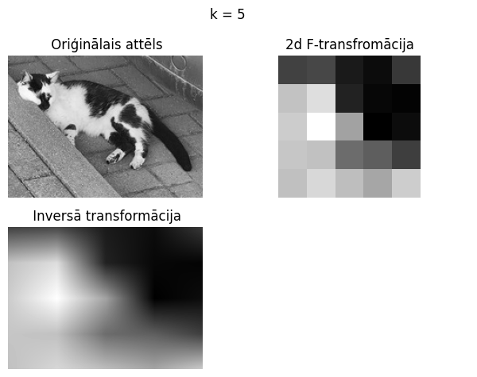

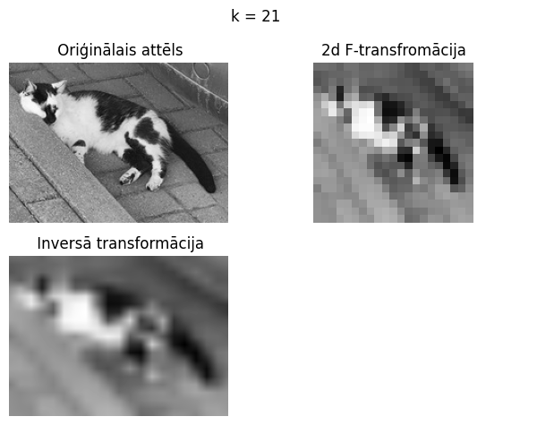

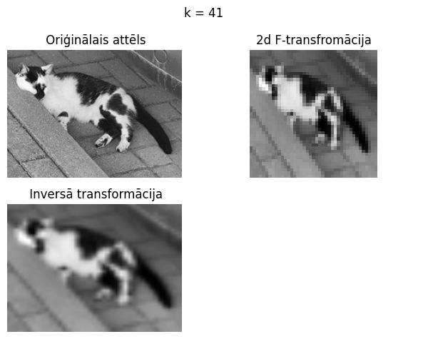

```python
Kv = [5,21,41]

img = Image.open("attels.jpg")
img_gray = img.convert('L')
img_array = np.array(img_gray)
attels_x = img_array.shape[0]
attels_y = img_array.shape[1]

for k in Kv:
    [A_x,hx, xx_xk] =bazes_fun(k,0,attels_x)
    [B_y, hy, xx_yk] =bazes_fun(k,0,attels_y)
    attels_transfromacija = np.zeros((k,k))

    # atrod diskrēto F-transfromāciju
    for it, Ai in enumerate(A_x):
        for jt, Bj in enumerate(B_y):
            skaititajs = 0
            saucejs = 0
            for i in range(attels_x):
                for j in range(attels_y):

                    skaititajs += img_array[i][j] * Ai([i,it])*Bj([j,jt])
                    saucejs += Ai([i,it])*Bj([j,jt])

            attels_transfromacija[it][jt] = skaititajs/saucejs

    fig, axes = plt.subplots(2, 2)
    inversa_transformacija =np.zeros((attels_x,attels_y))
    # Atrod inverso F-transfromāciju.
    for i in range(attels_x):
        for j in range(attels_y):
            for it, Ai in enumerate(A_x):
                for jt, Bj in enumerate(B_y):
                    inversa_transformacija[i][j] += attels_transfromacija[it][jt] *Ai([i,it])*Bj([j,jt])

    axes[0, 0].imshow(img_array, cmap='gray')
    axes[0, 0].axis('off')
    axes[0, 0].set_title(" Oriģinālais attēls")
    axes[0, 1].imshow(attels_transfromacija, cmap='gray')
    axes[0, 1].axis('off')
    axes[0, 1].set_title("2d F-transfromācija")
    axes[1, 0].imshow(inversa_transformacija, cmap='gray')
    axes[1, 0].axis('off')
    axes[1, 0].set_title(" Inversā transformācija")
    axes[1, 1].axis('off')
    fig.suptitle("k = " + str(k))
    plt.subplots_adjust(top=0.8)

    plt.tight_layout()
    plt.show()
```

Šī attēla izmēri ir 216x153 pikseļi. Aizstājot šo attēlu ar attēlu, kura izmēri ir krietni lielāki nerada būtiskas izmaiņas attēla transfromācijā atkarībā pret lielumu k. Taču lielākiem attēliem ir nepieciešams vairāk laika, lai atrastu tā transformāciju.

# F-transformācijas lietojums Volterra integrālvienādojumu risināšanā

#### Volterra integrālvienādojums

$$ u(t) = g(t) + \lambda \int^{t}_{a}k(t,s) u(s) ds $$

kur $t\in [a,b]$, $ \lambda \in \mathbb{R} \setminus \{ 0\} $, $k:[a,b]\times \mathbb{R} \to [a,b]$, $g:[a,b] \to \mathbb{R}$ un nezināmā funkcija $u:[a,b] \to \mathbb{R}$

Ir zināms, ja funkcija k ir integrējama un ierobežota un $ g \in L^{2}[a,b]$.

### Definīcija

Lai $f \in C[a,b] $ . Par lineāro Volterra (integrālo) operatoru $\mathcal{V} :C[a,b] \to C[a,b]$ sauc

$$ \mathcal{V}(f)(t) = \int^{t}_{a} f(s) ds $$

kur $t\in [a,b] $

### Lemma

Lai $ A = [A_{1}, \ldots , A_{n}] $ ir bāzes funkcijas intervālā [a,b]. Tad katram $i \in \{1, \ldots, n \}$ pielietojot Volterra operatoru $\mathcal{V}$ i-tajai bāzes funkcijai

$$ \mathcal{V}(A_{i})(t) = \int^{t}_{a} A_{i}(\tau) d \tau \approx \sum^{n}_{j=1} p_{i,j} A_{j}(t) $$

kur $ p_{i,j} = \int^{x_{j}}_{a} A_{i}(\tau) d \tau $, $i,j = 1,2, \ldots, n $

### Definīcija

Lai $A = [A_{1}, \ldots A_{n}] $ ir bāzes funkcijjas intervālā [a,b]. Volterra operatora matrica kopā C[a,b] attiecībā pret A ir $n\times n $ matrica $P = (p_{i,j})$, kas doti pēc iepriekšējās formulas.

### Sekas

Matrica

$$P = \frac{h}{2} \begin{bmatrix} 0 & 1 & 1 & 1 & \ldots & 1 & 1 & 1 \\ 0 & 1 & 2 & 2 & \ldots & 2 & 2 & 2 \\ 0 & 0 & 1 & 2 & \ldots & 2 & 2 & 2 \\ \vdots & \vdots & \vdots & \vdots & \ddots & \vdots & \vdots & \vdots \\ 0 & 0 & 0 & 0 & \ldots & 0 & 0 & 1 \\ \end{bmatrix} $$

### Teorēma

Lai $A(t) = [A_{1}(t), \ldots, A_{n}(t)]^T$ ir bāzes funkciju vektors un $f\in C[a,b]$. Tad

$$ \mathcal{V}[f](t) \approx F^{T}[f]P A(t) $$

kur F[f] ir funkcijas f F-transformācija attiecībā pret bāzes funkcijām $A_{1}, \ldots , A_{n}$

```python
def matrica_p(k,h):
    P = np.zeros((k,k))
    P[0] +=1
    P[0][0] = 0
    for id in range(1,k):
        P[id][id] = 1
        if id < k-1:
            P[id][id+1:k] =2
    P = P * h/2
    return P
```

Tālāk tiek piedāvāts piemērs, kurā tiek ilustrēta iepriekš minētā teorija. Tiek lietots iepriekš minētais polinoms intervālā [0,3]. Katrā punktā atrasta $\mathcal{V}$ un F transformācija.

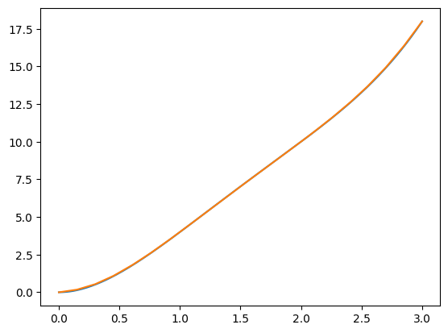

```python
f = lambda x: (x-1) * (x-2)* ( 2*x -3 ) + 6
k=21
a=0
b=3

[A,h,xx_k] = bazes_fun(k,a,b)
F_t = F_transform(f,A,h,xx_k)
P = matrica_p(k,h)

X = np.arange(a,b+0.01,0.01)
Y_VoltTrans = []
Y_FTrans = []

for xi in X:
    # Volterra transformācijas vŗtība dotajā punktā
    Y_VoltTrans.append(integrate.quad(lambda x: f(x) , a, xi)[0])

    # Katrā punktā atrod vērtības vektoram A(t)
    A_vektors = np.zeros((k,1))
    for id, fun in enumerate(A):
        A_vektors[id][0] = fun([xi,id])
    # F-transormācijas vēr'tiba dotajā punktā
    Y_FTrans.append(np.dot( np.dot(F_t,P),A_vektors)[0])

plt.plot(X,Y_VoltTrans)
plt.plot(X, Y_FTrans)
plt.show()
```

### Definīcija

Lai $f\in C[a,b]$. un lai $k(t,s)\in [a,b]\times [a,b]$ būtu nepārtrauktai kodola funkcija apakškopā $a \leq s \leq t \leq b$. Par (lineāro) Volterra-kernel operatoru $ \mathcal{V}_{k}: C[a,b] \to C[a,b]$ ir definēts

$$ \mathcal{V}_{k}(f)(t) = \int^{t}_{a} k(t,s) f(s) ds $$

kur $t\in [a,b]$

Tagad sākotnējo vienādojumu var pārrakstīt

$$ u(t) = g(t) + \lambda \mathcal{V}_{k}(u)(t) $$

### Teorēma

Lai $A = [A_{1}, \ldots , A_{n}] $ ir bāzes funkcijas intervālā [a,b], $u\in C([a,b])$, $k \in C^{2}([a,b] \times [a,b]) $

un $A(t) = (A_{1}(t),\ldots, A_{n}(t))$, tad

$$ \mathcal{V}_{k}(u)(t) \approx U^{T}(K^{T} \odot P)A(t) $$

kur $ U = (U_{1},\ldots , U_{n}) $ ir funkcijas u F-transfromācija, K ir funkcijas k F-transformācijas matrica attiecībā pret funkcijām $A = (A_{1}, \ldots, A_{n}) $

## Skaitliskā metode integrālvienādojuma risināšanai

Vēlreiz aplūko vienādojumu

$$ u(t) = g(t) + \lambda \mathcal{V}_{k}(u)(t) $$

aizvieto funkcijas ar to inversām F-transformācijām un iegūst

$$ U^{T} A(t) = G^{T}A(t) + \lambda U^{T}(K^{T} \odot P) A(t) $$

Izslēdz funkciju A(t)

$$ U^{T} = G^{T} + \lambda U^{T}(K^{T} \odot P) $$

un no dotā vienādojuma izsaka matricu U

$$ U = (I - \lambda (K^{T} \odot P^{T}) )^{-1} G$$

kas ļauj atrast funkcijas u F-transformāciju. Tālāk atliek atrast inverso transformāciju, reizinot $ \hat{ u}_{n} = U A(t)$

#### Piemēri

$$ u(t) = 1 - \int^{t}_{a} (t-s) u(s) ds $$

kur $t\in [0,1]$. Vienādojuma atrisinājums ir $ u(t) = cos(t)$

```python
def _2d_transfromacija(f,A,k,h):
    F_t_2d = np.zeros((k,k))

    for i in range(0,k):
        for j in range(0,k):
            F_t_2d[i][j] = integrate.dblquad(lambda y,x: f([y,x])* A[i]([y,i]) *A[j]([x,j]), a, b, a, b)[0]


    F_t_2d[:,0] *= 2
    F_t_2d[:,-1] *= 2
    F_t_2d[0, :] *= 2
    F_t_2d[-1, :] *= 2
    F_t_2d *= 1/(h**2)


    return F_t_2d
```

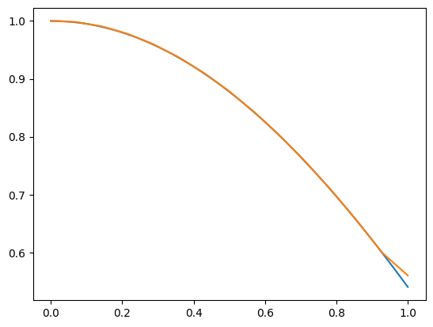

```python
#funkcija g = 1
g_t = lambda x: 1

# Kodola funkcija k(t,s)
kodola_fun = lambda x:  (x[0] - x[1])

lmbda = -1

k=15
a=0
b=1

[A,h,xx_k] = bazes_fun(k,a,b)
F_t = F_transform(g_t,A,h,xx_k)
P = matrica_p(k,h)

# Atrod kodola funkcijas trasnfromāciju
# ! Šis solis ir lēns
K_t = _2d_transfromacija(kodola_fun,A,k,h)


# Funkcijas U F-transformācija
U = np.transpose(  np.dot( np.linalg.inv(  np.identity(k) - lmbda *np.transpose (  np.transpose(K_t) * P) ) , F_t) )

X = np.arange(a,b+0.01,0.01)
Y_Trans = []

plt.plot(X, np.cos(X))

for xi in X:
    A_vektors = np.zeros((k,1))
    for id, fun in enumerate(A):
        A_vektors[id] = fun([xi,id])
    Y_Trans.append(np.dot(U,A_vektors)[0])

plt.plot(X,Y_Trans)
plt.show()
```

#### Piemērs

$$ u(t)= 1-t- \frac{t^{2}}{2} + \int^{t}_{0} (t-s)u(s) ds $$

Ar atrisinājumu $ u(t) = 1- sinh(t)$. Šeit $t \in [0,1]$

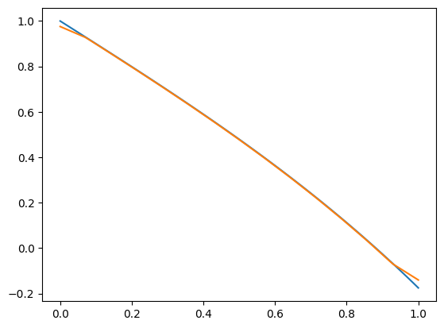

```python
#funkcija g = 1 - t - t^2/2
g_t = lambda x: 1 - x- x**2 / 2

# Kodola funkcija k(t,s)
kodola_fun = lambda x:  (x[0] - x[1])

lmbda = 1

k=15
a=0
b=1

[A,h,xx_k] = bazes_fun(k,a,b)
F_t = F_transform(g_t,A,h,xx_k)
P = matrica_p(k,h)

# Atrod kodola funkcijas trasnfromāciju
# ! Šis solis ir lēns
K_t = _2d_transfromacija(kodola_fun,A,k,h)


# Funkcijas U F-transformācija
U = np.transpose(  np.dot( np.linalg.inv(  np.identity(k) - lmbda *np.transpose (  np.transpose(K_t) * P) ) , F_t) )

X = np.arange(a,b+0.01,0.01)
Y_Trans = []

plt.plot(X, 1 - np.sinh(X))

for xi in X:
    A_vektors = np.zeros((k,1))
    for id, fun in enumerate(A):
        A_vektors[id] = fun([xi,id])
    Y_Trans.append(np.dot(U,A_vektors)[0])

plt.plot(X,Y_Trans)
plt.show()
```

#### Piemērs

$$ u(t) = e^{t} - \frac{1}{t+1}(e^{t(t+1)}-1) + \int^{t}_{0}e^{ts}u(t)dt$$

Ar atrisinājumu $e^{t}$. Šeit $t\in [0,1]$

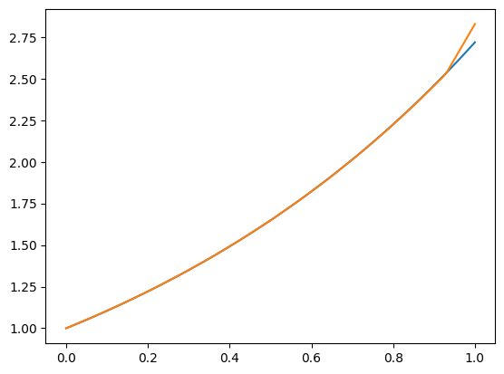

```python
#funkcija g = 1 - t - t^2/2
g_t = lambda x: np.exp(x) - 1/(x+1)* ( np.exp(x*(x+1)) -1 )

# Kodola funkcija k(t,s)
kodola_fun = lambda x: np.exp(x[0] * x[1])

lmbda = 1

k=15
a=0
b=1

[A,h,xx_k] = bazes_fun(k,a,b)
F_t = F_transform(g_t,A,h,xx_k)
P = matrica_p(k,h)

# Atrod kodola funkcijas trasnfromāciju
# ! Šis solis ir lēns
K_t = _2d_transfromacija(kodola_fun,A,k,h)


# Funkcijas U F-transformācija
U = np.transpose(  np.dot( np.linalg.inv(  np.identity(k) - lmbda *np.transpose (  np.transpose(K_t) * P) ) , F_t) )

X = np.arange(a,b+0.01,0.01)
Y_Trans = []

plt.plot(X, np.exp(X))

for xi in X:
    A_vektors = np.zeros((k,1))
    for id, fun in enumerate(A):
        A_vektors[id] = fun([xi,id])
    Y_Trans.append(np.dot(U,A_vektors)[0])

plt.plot(X,Y_Trans)
plt.show()
```

Avoti:

1. Irina Perfilieva, , *Fuzzy transfrom: Theory and applications* , Fuzzy Sets and Systems, Vol 157(8), 2006, https://doi.org/10.1016/j.fss.2005.11.012
2. Irina Perfilieva, Shokrollah Ziari, Rahele Nuraei, Thi Minh Tam Pham , *F-transform utility in the operational-matrix approach to the Volterra integral equation*, Fuzzy Sets and Systems, Vol 475, 2024, https://doi.org/10.1016/j.fss.2023.108764